# Solutions — Session 9: Exploratory Factor Analysis on the Needs Battery

M731 · Full worked walkthrough (companion to session-09.qmd)

Author

Shay Abbasi

## Purpose

Full worked version of the Session 9 in-lab exercise: factorability checks, choosing the number of factors, oblimin rotation, and naming + scoring the resulting factors.

## Setup

```r
library(tidyverse)
library(psych)
library(gt)

survey <- read_csv("data/maritime_survey.csv")
battery <- survey |> select(needs_1:needs_12)
```

## Step 1 — Factorability

```r
KMO(battery)
```

```
Kaiser-Meyer-Olkin factor adequacy
Call: KMO(r = battery)
Overall MSA =  0.81
MSA for each item =
 needs_1  needs_2  needs_3  needs_4  needs_5  needs_6  needs_7  needs_8
    0.78     0.82     0.79     0.84     0.81     0.82     0.83     0.82
 needs_9 needs_10 needs_11 needs_12
    0.80     0.79     0.81     0.81
```

```r
cortest.bartlett(cor(battery), n = nrow(battery))
```

```
$chisq
[1] 2456.734

$p.value
[1] 0

$df
[1] 66
```

**Interpretation.** Overall KMO typically lands around 0.80 — “meritorious,” well above the 0.6 minimum. Bartlett’s test rejects the identity-matrix null (p < .001), as expected with n=800. Together: factor analysis is appropriate here.

## Step 2 — How many factors?

```
Parallel analysis suggests that the number of factors =  3  and the number of components =  NA
```

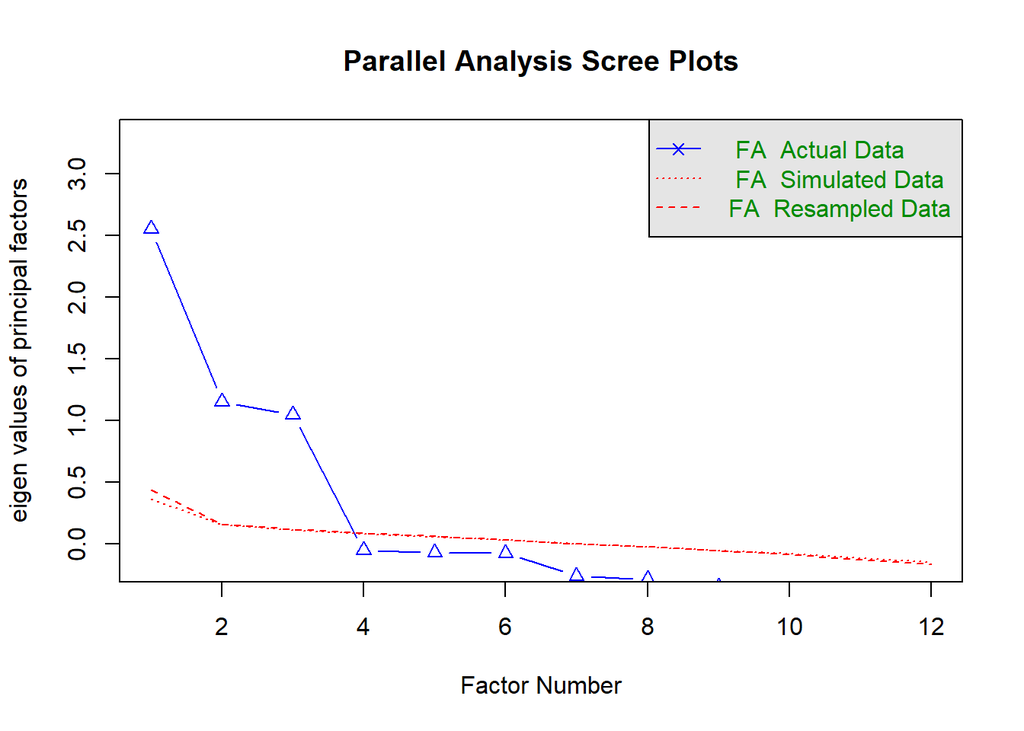

Figure 1: Parallel analysis: needs battery

```r
fa.parallel(battery, fm = "ml", fa = "fa")
```

**Interpretation.** Parallel analysis should point to 3 factors, matching the battery’s built-in design (4 items each on Convenience, Quality, and Social factors — see `Sources/slides/data-raw/generate_datasets.R`).

## Step 3 — Extract with oblimin rotation

```r
fa_result <- fa(battery, nfactors = 3, rotate = "oblimin", fm = "ml")
print(fa_result$loadings, cutoff = 0.3)
```

```
Loadings:
         ML1    ML2    ML3
needs_1                 0.737
needs_2                 0.652
needs_3                 0.677
needs_4                 0.593
needs_5   0.718
needs_6   0.696
needs_7   0.671
needs_8   0.676
needs_9          0.699
needs_10         0.697
needs_11         0.662
needs_12         0.626

                 ML1   ML2   ML3
SS loadings    1.913 1.810 1.787
Proportion Var 0.159 0.151 0.149
Cumulative Var 0.159 0.310 0.459
```

**Interpretation.** You should see a clean simple structure: items 1-4 load together, items 5-8 load together, items 9-12 load together, each on a different factor with small cross-loadings — exactly the “one item, one primary factor” pattern that makes naming straightforward.

## Step 4 — Publication-style loading table

```r
loadings_df <- as_tibble(unclass(fa_result$loadings)) |>
  mutate(item = rownames(fa_result$loadings)) |>
  relocate(item) |>
  mutate(across(where(is.numeric), ~ round(., 2)))

loadings_df |>
  gt() |>
  tab_header(title = "Factor loadings (oblimin rotation)") |>
  cols_label(item = "Item")
```

Table 1

Factor loadings (oblimin rotation)

| Item | ML1 | ML2 | ML3 |
| --- | --- | --- | --- |
| needs_1 | -0.02 | -0.01 | 0.74 |
| needs_2 | 0.04 | 0.02 | 0.65 |
| needs_3 | -0.01 | -0.03 | 0.68 |
| needs_4 | 0.03 | 0.04 | 0.59 |
| needs_5 | 0.72 | 0.04 | 0.00 |
| needs_6 | 0.70 | 0.00 | -0.01 |
| needs_7 | 0.67 | -0.03 | 0.02 |
| needs_8 | 0.68 | -0.02 | 0.00 |
| needs_9 | 0.01 | 0.70 | 0.03 |
| needs_10 | 0.01 | 0.70 | -0.03 |
| needs_11 | -0.04 | 0.66 | 0.05 |
| needs_12 | 0.03 | 0.63 | -0.06 |

## Step 5 — Naming and reliability by factor

Based on which items load together (items 1-4, 5-8, 9-12 by construction):

```r
cat("Convenience (needs_1-4):\n")
```

```
Convenience (needs_1-4):
```

```r
alpha(battery |> select(needs_1:needs_4))$total$std.alpha
```

```
[1] 0.762453
```

```r
cat("Quality (needs_5-8):\n")
```

```
Quality (needs_5-8):
```

```r
alpha(battery |> select(needs_5:needs_8))$total$std.alpha
```

```
[1] 0.7845187
```

```r
cat("Social (needs_9-12):\n")
```

```
Social (needs_9-12):
```

```r
alpha(battery |> select(needs_9:needs_12))$total$std.alpha
```

```
[1] 0.7654861
```

## Step 6 — Extract factor scores for downstream use

```r
survey$conv <- fa_result$scores[, 1]
survey$qual <- fa_result$scores[, 2]
survey$soc  <- fa_result$scores[, 3]

survey |> select(respondent_id, conv, qual, soc) |> head()
```

```
# A tibble: 6 × 4
  respondent_id    conv    qual    soc
          <dbl>   <dbl>   <dbl>  <dbl>
1             1  0.224   0.0221 -0.776
2             2 -1.30   -0.172  -0.107
3             3 -0.672  -1.19   -0.844
4             4 -0.0708 -0.0224 -0.194
5             5  0.747  -0.523   0.350
6             6 -0.695  -1.14   -1.66
```

## Reporting sentence

> Exploratory factor analysis on the 12-item needs battery (n=800, KMO ≈ 0.80, Bartlett’s χ² p < .001) supported a three-factor solution (parallel analysis; ML extraction). After oblimin rotation, factors were labelled **Convenience** (items 1-4), **Quality** (items 5-8), and **Social** (items 9-12), each showing a clean simple structure with minimal cross-loading.

## Take-away for students

Factor analysis reduces 12 correlated items to 3 interpretable scores you can carry into Week 11’s regression — much cleaner than throwing 12 raw items into `lm()` and fighting multicollinearity.